# Bellabeat: Marketing Strategy for Smart Devices

July 2021

## Business Task

### **Step 1:**

Use data from fitness trackers to gain insights on user behaviour.

### **Step 2:**

Use insights to guide marketing strategy

## Our Data

- **Sample size:** 35 fitbit users
- **Duration:** 2 months (12/03/16 - 12/05/16)
- **Attributes:** activity (intensity, duration, distance), step count, sleep, weight

## Key Findings

**Daily user averages:**

- Step count: 7253
- Distance covered: 5.2 kilometers
- Time spent sedentary: 16 hours 27 minutes

Fitbit users are more active than the average person (~5000 steps) BUT are still mostly inactive!

## Key Findings cont.

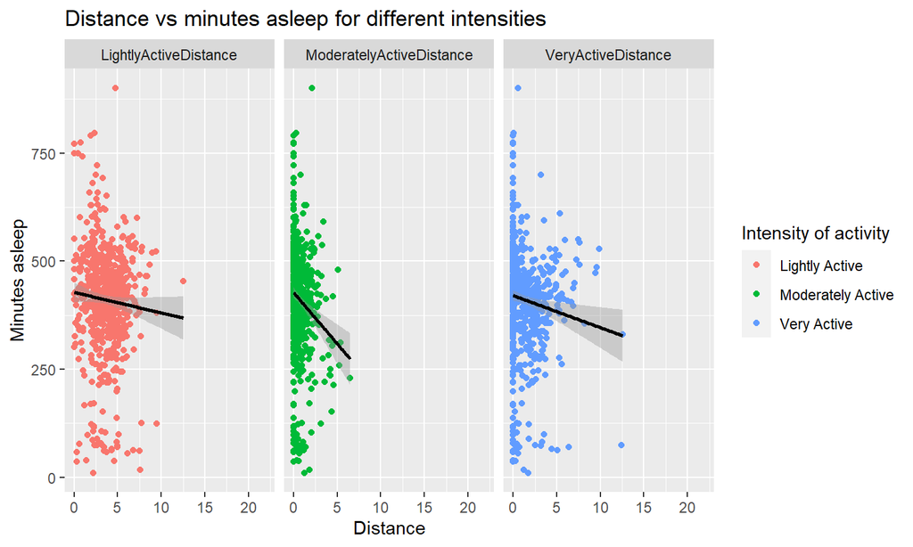

Activity can help regulate sleep. **Moderate intensity** appears to have the best effect.

## Key Findings cont.

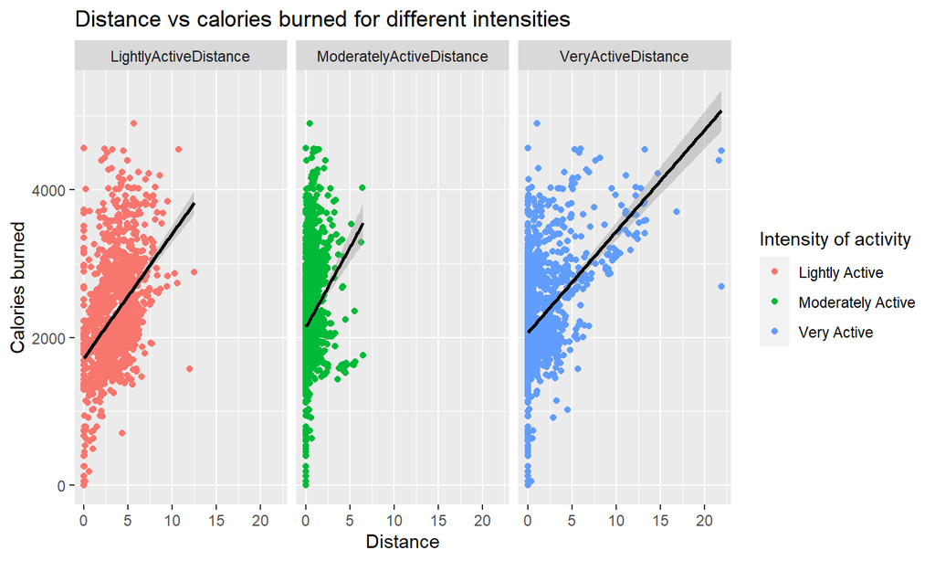

Measuring calories burned can help regulate weight. **Quantity** of activity is far more important than **intensity**.

## Recommendations

Incorporate the following ideas:

- People with fitness trackers are more active than the average person.
- Moderate activity is beneficial for sleep regulation and quality.
- Meeting activity goals can help in weight loss or weight management.
- Devices can track progress, and ensure the above goals are being met.